# Assignment Three Project

Elphas Oyugi, Paul Hoos

2025-06-14

#Loading Shapefile for Sachsen as a geographic region as an area of interest, #Listing the files in the directory path folder

```
## character(0)
```

#Wrangling the shapefile data to execute analysis process, filtering data for Sachsen and visualization

```
## [1] "/Users/paulhoos/Assignment 3/data/gadm41_DEU_shp/gadm41_DEU_1.shp"
```

```
##  [1] "GID_1"     "GID_0"     "COUNTRY"   "NAME_1"    "VARNAME_1" "NL_NAME_1"
##  [7] "TYPE_1"    "ENGTYPE_1" "CC_1"      "HASC_1"    "ISO_1"     "geometry"
```

```
##  [1] "Baden-Württemberg"      "Bayern"                 "Berlin"
##  [4] "Brandenburg"            "Bremen"                 "Hamburg"
##  [7] "Hessen"                 "Mecklenburg-Vorpommern" "Niedersachsen"
## [10] "Nordrhein-Westfalen"    "Rheinland-Pfalz"        "Saarland"
## [13] "Sachsen"                "Sachsen-Anhalt"         "Schleswig-Holstein"
## [16] "Thüringen"
```

# Plotting Sachsen as a geographical area of interest and visualization

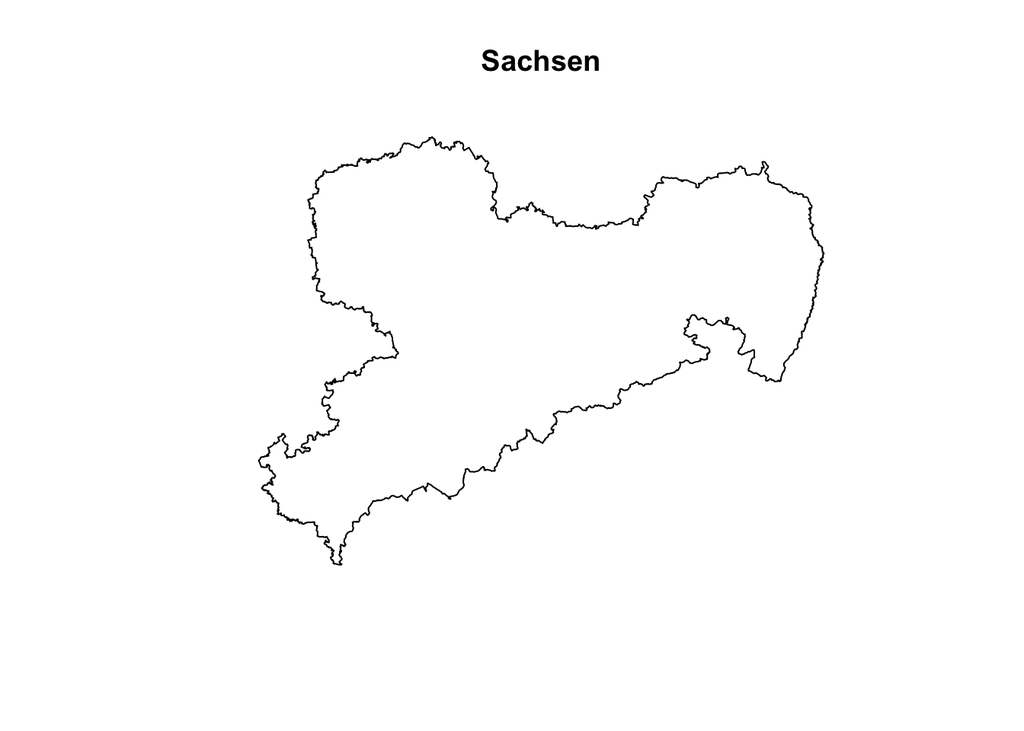

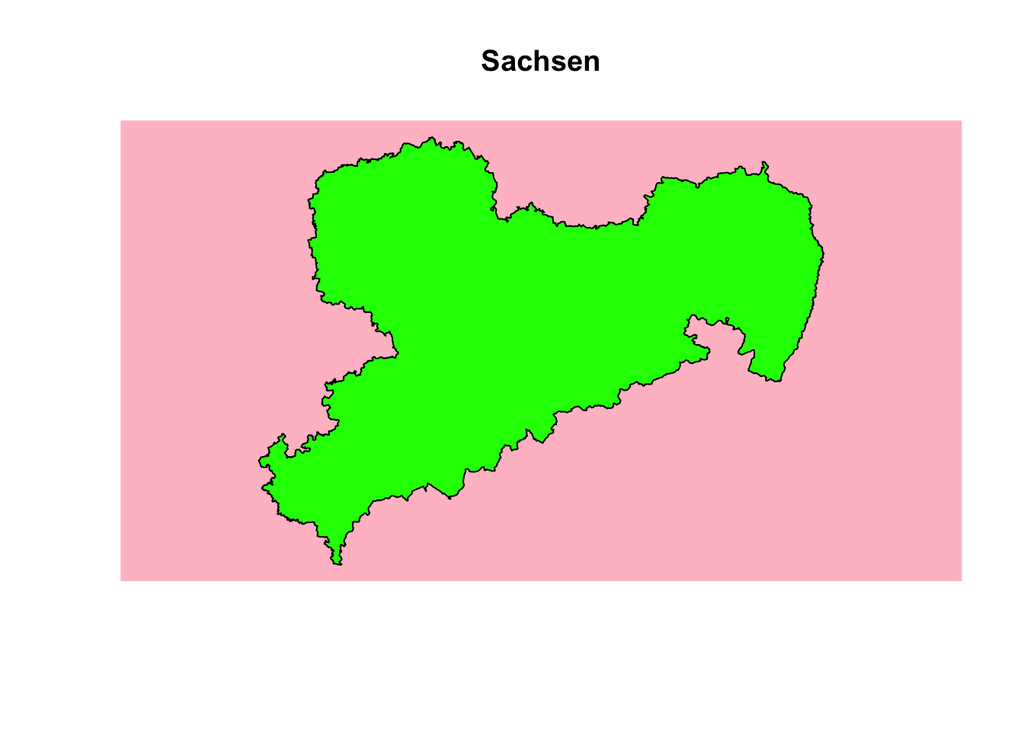

#Descriptive summary of the shapefile data for Sachsen

```
##     GID_1              GID_0             COUNTRY             NAME_1
##  Length:1           Length:1           Length:1           Length:1
##  Class :character   Class :character   Class :character   Class :character
##  Mode  :character   Mode  :character   Mode  :character   Mode  :character
##   VARNAME_1          NL_NAME_1            TYPE_1           ENGTYPE_1
##  Length:1           Length:1           Length:1           Length:1
##  Class :character   Class :character   Class :character   Class :character
##  Mode  :character   Mode  :character   Mode  :character   Mode  :character
##      CC_1              HASC_1             ISO_1                    geometry
##  Length:1           Length:1           Length:1           MULTIPOLYGON :1
##  Class :character   Class :character   Class :character   epsg:4326    :0
##  Mode  :character   Mode  :character   Mode  :character   +proj=long...:0
```

# Now its time to load Raster data for precipation and elevation,

However,shapefile data also loaded again to filter Sachsen

#Build the sum of the months for annual precipation data (Crop and mask first for faster calculation)

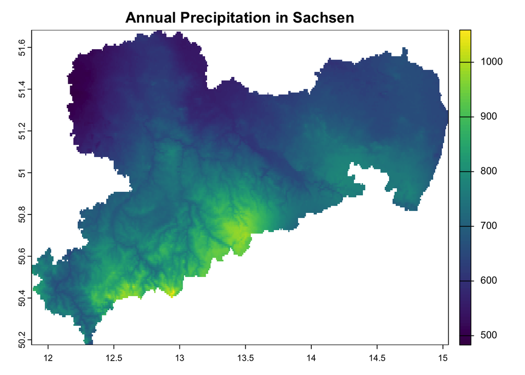

# Now crop and mask raster elevation data to Sachsen only as a geographic region

# Combine elevation and precipation

#sanity check

```
##   longitude latitude elevation precip
## 1  11.87917 50.52083       572    830
## 2  11.87917 50.52917       556    819
## 3  11.87917 50.53750       546    808
## 4  11.87917 50.54583       508    781
## 5  11.87917 50.55417       510    781
## 6  11.88750 50.43750       626    875
```

```
##    longitude        latitude       elevation          precip
##  Min.   :11.88   Min.   :50.18   Min.   :  57.0   Min.   : 483.0
##  1st Qu.:12.68   1st Qu.:50.81   1st Qu.: 142.0   1st Qu.: 634.0
##  Median :13.18   Median :51.10   Median : 240.0   Median : 689.0
##  Mean   :13.35   Mean   :51.05   Mean   : 294.3   Mean   : 696.3
##  3rd Qu.:14.02   3rd Qu.:51.31   3rd Qu.: 402.0   3rd Qu.: 751.0
##  Max.   :15.04   Max.   :51.68   Max.   :1173.0   Max.   :1059.0
```

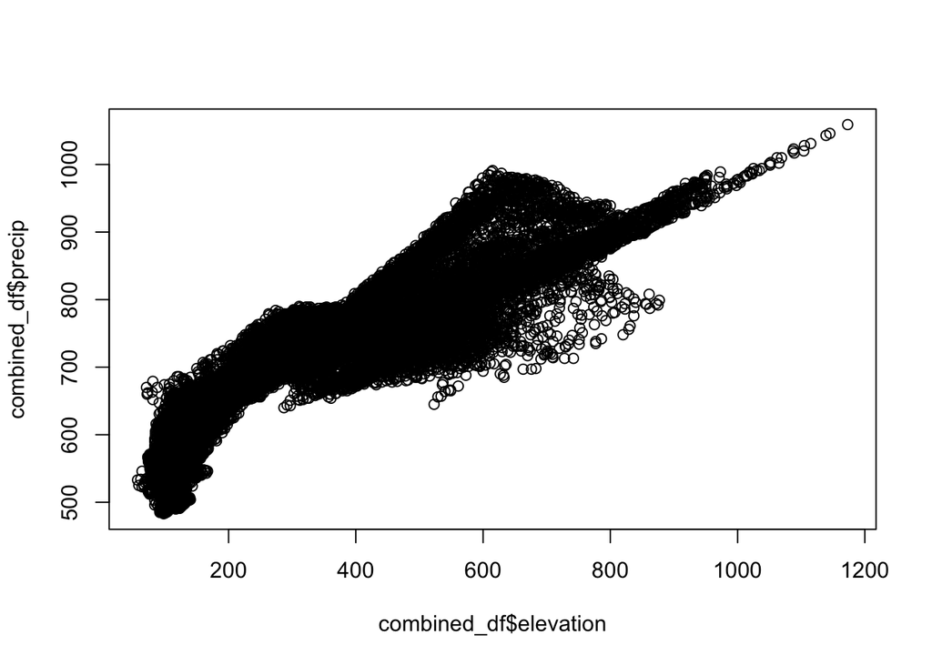

#Analyze and visualize

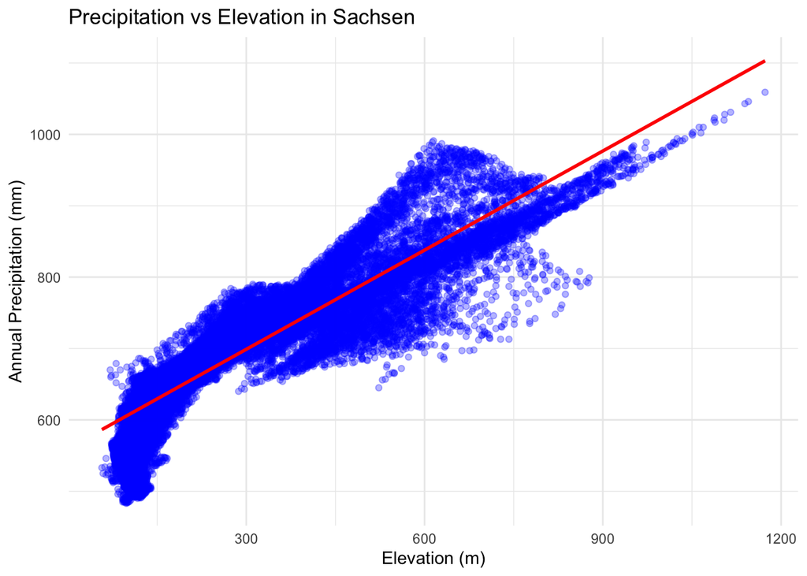

```
##
## Call:
## lm(formula = precip ~ elevation, data = combined_df)
##
## Residuals:
##      Min       1Q   Median       3Q      Max
## -191.687  -24.169    7.633   25.927  146.233
##
## Coefficients:
##              Estimate Std. Error t value Pr(>|t|)
## (Intercept) 5.600e+02  4.049e-01  1383.2   <2e-16 ***
## elevation   4.630e-01  1.163e-03   398.2   <2e-16 ***
## ---
## Signif. codes:  0 '***' 0.001 '**' 0.01 '*' 0.05 '.' 0.1 ' ' 1
##
## Residual standard error: 40.52 on 35073 degrees of freedom
## Multiple R-squared:  0.8189, Adjusted R-squared:  0.8189
## F-statistic: 1.586e+05 on 1 and 35073 DF,  p-value: < 2.2e-16
```

#ANALYSIS OF THE OUTPUT ABOVE - elevation VS precipation;

The scatterplot shows a strong positive relationship between elevation and annual precipitation in Sachsen. As elevation increases, precipitation tends to rise as well. The red regression line indicates a clear upward trend, suggesting that higher-altitude areas receive more rainfall — likely due to orographic effects. While there is some spread in the data at mid elevations (500–700 m), the overall correlation appears strong and linear.

#Statistical Relationship: Precipitation ~ Elevation

```
##
## Call:
## lm(formula = precip ~ elevation, data = combined_df)
##
## Residuals:
##      Min       1Q   Median       3Q      Max
## -191.687  -24.169    7.633   25.927  146.233
##
## Coefficients:
##              Estimate Std. Error t value Pr(>|t|)
## (Intercept) 5.600e+02  4.049e-01  1383.2   <2e-16 ***
## elevation   4.630e-01  1.163e-03   398.2   <2e-16 ***
## ---
## Signif. codes:  0 '***' 0.001 '**' 0.01 '*' 0.05 '.' 0.1 ' ' 1
##
## Residual standard error: 40.52 on 35073 degrees of freedom
## Multiple R-squared:  0.8189, Adjusted R-squared:  0.8189
## F-statistic: 1.586e+05 on 1 and 35073 DF,  p-value: < 2.2e-16
```

#Summary of the statistical relationship result above;

There is a strong and statistically significant positive relationship between elevation and annual precipitation in Sachsen. The model explains approximately 82% of the variation in precipitation. On average, annual precipitation increases by 0.46 mm for every 1 meter increase in elevation. This supports the hypothesis that elevation plays a major role in local climate conditions within the region.

#Make a nice map that compares elevation in Saxony to annual precipation

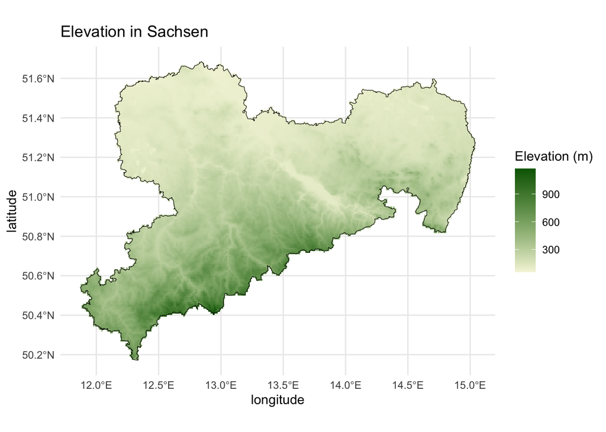

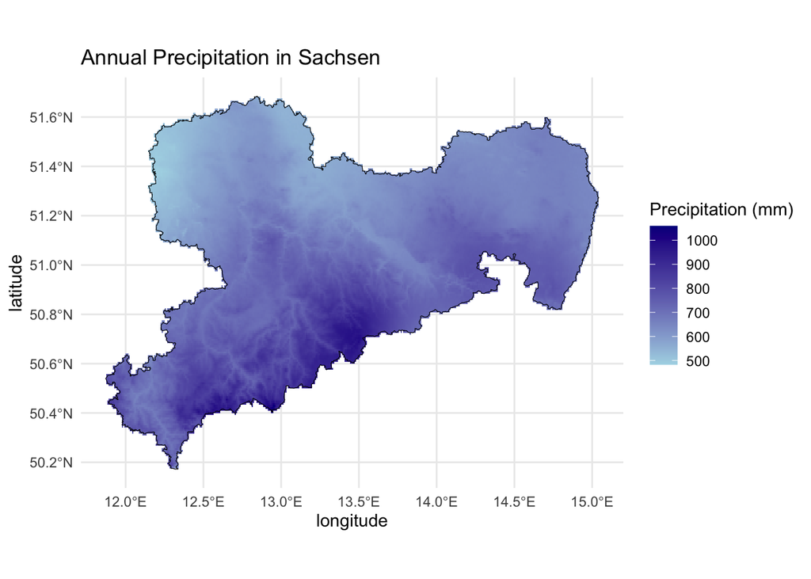